# Sea Duck Incubation Constancy Analysis: 2011–2025

**Best fit model summary and diagnostics**

```r
summary(m_best)
```

```
Linear mixed model fit by maximum likelihood . t-tests use Satterthwaite's
  method [lmerModLmerTest]
Formula:
as.formula(paste("logit_const ~ z_DOY * Species + z_stage + z_TMAX + z_AWND +",
    re_form))
   Data: constancy_camera
Control: ctrl

      AIC       BIC    logLik -2*log(L)  df.resid
   3518.4    3584.6   -1745.2    3490.4       823

Scaled residuals:
    Min      1Q  Median      3Q     Max
-6.0998 -0.2775 -0.0034  0.3790  3.8943

Random effects:
 Groups   Name        Variance Std.Dev.
 Nest_ID  (Intercept) 0.4718   0.6869
 Year     (Intercept) 0.1316   0.3628
 Residual             3.4528   1.8582
Number of obs: 837, groups:  Nest_ID, 91; Year, 11

Fixed effects:
                   Estimate Std. Error        df t value Pr(>|t|)
(Intercept)         4.04268    0.23606  36.32825  17.126  < 2e-16 ***
z_DOY              -0.81664    0.23272 141.93748  -3.509 0.000603 ***
SpeciesLTDU        -2.60550    0.38367  52.19603  -6.791 1.05e-08 ***
SpeciesSPEI        -0.23470    0.27778  59.80418  -0.845 0.401543
SpeciesSTEI        -2.40482    0.33300  57.43212  -7.222 1.31e-09 ***
z_stage             0.03474    0.14285  64.87314   0.243 0.808620
z_TMAX             -0.11165    0.07359 715.53394  -1.517 0.129676
z_AWND             -0.07113    0.07102 790.75386  -1.002 0.316858
z_DOY:SpeciesLTDU   0.74740    0.25960 471.74453   2.879 0.004171 **
z_DOY:SpeciesSPEI   0.30437    0.25386 478.55819   1.199 0.231140
z_DOY:SpeciesSTEI   0.76493    0.26484 363.75256   2.888 0.004105 **
---
Signif. codes:  0 '***' 0.001 '**' 0.01 '*' 0.05 '.' 0.1 ' ' 1

Correlation of Fixed Effects:
            (Intr) z_DOY  SpLTDU SpSPEI SpSTEI z_stag z_TMAX z_AWND z_DOY:SL
z_DOY        0.234
SpeciesLTDU -0.541 -0.315
SpeciesSPEI -0.625 -0.092  0.374
SpeciesSTEI -0.597 -0.260  0.486  0.451
z_stage     -0.209 -0.554  0.400 -0.039  0.288
z_TMAX       0.015 -0.024 -0.024 -0.035 -0.029 -0.018
z_AWND       0.009 -0.048 -0.018  0.012 -0.021 -0.048  0.169
z_DOY:SLTDU -0.093 -0.584  0.077  0.096  0.094 -0.061 -0.005  0.078
z_DOY:SSPEI -0.093 -0.579  0.044  0.261  0.065 -0.073  0.006  0.022  0.560
z_DOY:SSTEI -0.107 -0.642  0.099  0.086 -0.115  0.051  0.027  0.086  0.548
            z_DOY:SSP
z_DOY
SpeciesLTDU
SpeciesSPEI
SpeciesSTEI
z_stage
z_TMAX
z_AWND
z_DOY:SLTDU
z_DOY:SSPEI
z_DOY:SSTEI  0.540
```

```r
AIC(m_best)
```

```
[1] 3518.398
```

```r
logLik(m_best)
```

```
'log Lik.' -1745.199 (df=14)
```

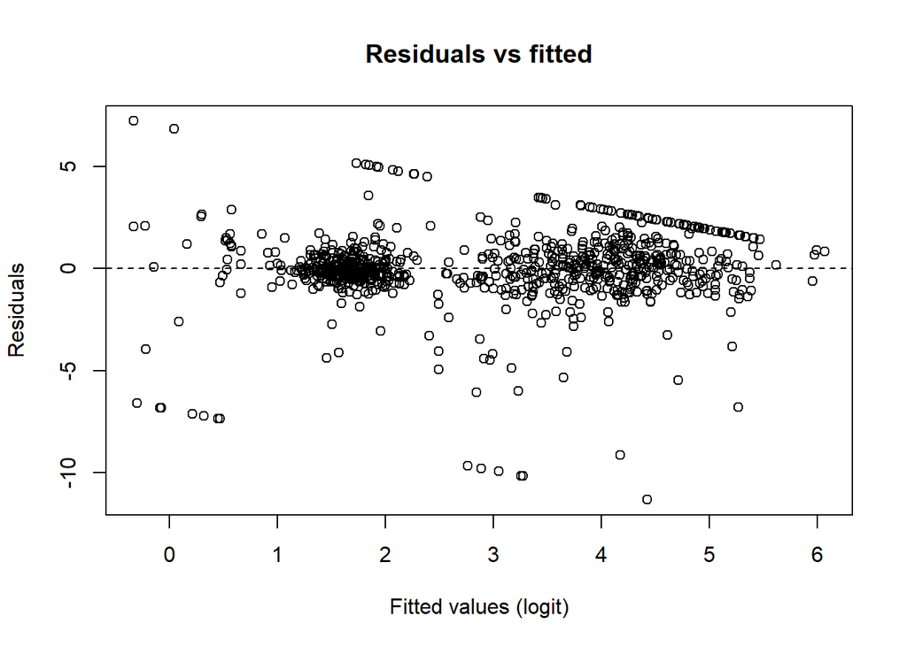

```r
### Residual diagnostics
resid_raw   <- residuals(m_best)
resid_pear  <- residuals(m_best, type="pearson")
fitted_vals <- fitted(m_best)

# Residuals vs fitted
plot(fitted_vals, resid_raw,
     xlab= "Fitted values (logit)", ylab ="Residuals",
     main="Residuals vs fitted"); abline(h=0, lty=2)
```

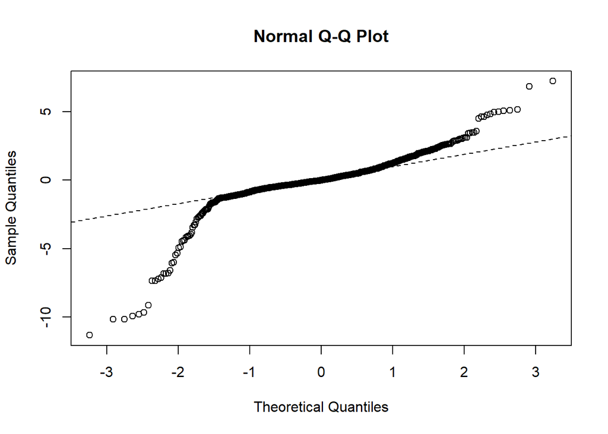

```r
# Normal Q-Q plot
qqnorm(resid_raw); qqline(resid_raw, lty=2)
```

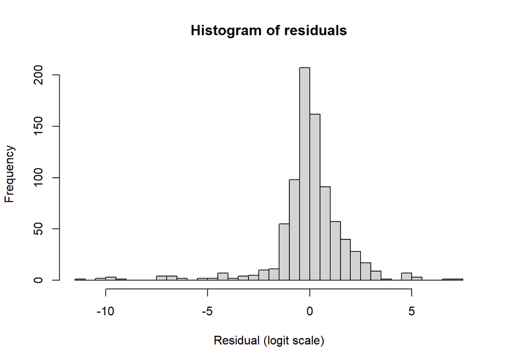

```r
# Histogram of residuals
hist(resid_raw, breaks=40, main="Histogram of residuals", xlab="Residual (logit scale)")
```

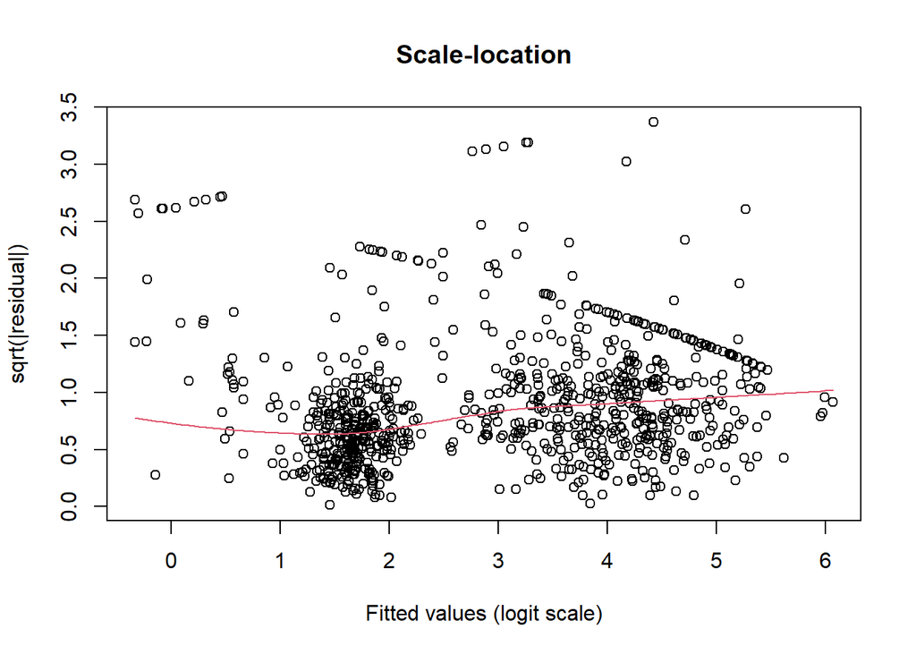

```r
# Scale-location (variance vs mean) – optional quick check
plot(fitted_vals, sqrt(abs(resid_raw)),
     xlab= "Fitted values (logit scale)", ylab="sqrt(|residual|)",
     main="Scale-location"); lines(lowess(fitted_vals, sqrt(abs(resid_raw))), col=2)
```

```r
#Primary figure: Predicted daily IC vs DOY, by species
inv_logit <- function(x) plogis(x)


# build prediction grid
```

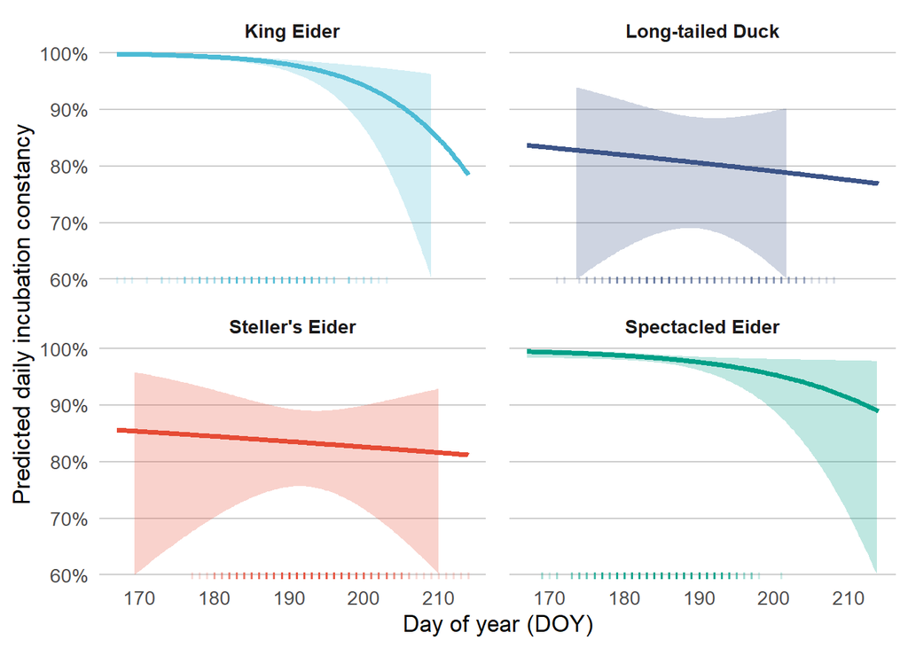

```r
doy_seq <- seq(
  min(constancy_camera$DOY, na.rm = TRUE),
  max(constancy_camera$DOY, na.rm = TRUE),
  length.out = 200
)
pred_grid <- expand.grid(
  DOY     = doy_seq,
  Species = levels(constancy_camera$Species)
) %>%
  as_tibble() %>%
  mutate(
    # recreate z_DOY using same mean/sd as analysis data
    z_DOY = (DOY - mean(constancy_camera$DOY, na.rm = TRUE)) /
      sd(constancy_camera$DOY, na.rm = TRUE),

    # hold other standardized covariates at their means (0 if scaled)
    z_stage = 0,
    z_TMAX  = 0,
    z_AWND  = 0
  )

# Fixed-effect predictions, and SEs on link scale
# Use the fixed-effects design matrix and variance-covariance matrix
X <- model.matrix(
  delete.response(terms(m_best)),
  pred_grid
)

b <- fixef(m_best)
V <- vcov(m_best)

# Align columns
X <- X[, names(b), drop = FALSE]

fit_link <- as.vector(X %*% b)
se_link  <- sqrt(pmax(0, diag(X %*% V %*% t(X))))

pred_grid <- pred_grid %>%
  mutate(
    fit_link = fit_link,
    se_link  = se_link,
    lo_link  = fit_link - 1.96 * se_link,
    hi_link  = fit_link + 1.96 * se_link,
    fit = inv_logit(fit_link),
    lo  = inv_logit(lo_link),
    hi  = inv_logit(hi_link)
  )

# Relabel species with common names and assign palette.
pred_plot <- pred_grid %>%
  mutate(
    Species = recode_factor(Species, !!!species_labels)
  )

# prep data for x-axis rugs
raw_plot <- constancy_camera %>%
  dplyr::filter(!is.na(DOY), !is.na(Species)) %>%
  mutate(Species = recode_factor(Species, !!!species_labels))

# Pub-quality figure
Fig_primary <- ggplot() +
  geom_ribbon(
    data = pred_plot,
    aes(x = DOY, ymin = lo, ymax = hi, fill = Species),
    alpha = 0.25,
    linewidth = 0
  ) +
  geom_rug(
  data = raw_plot,
  aes(x = DOY, color = Species),
  sides = "b",
  alpha = 0.2,
  inherit.aes = FALSE
) +
  # prediction lines
  geom_line(
    data = pred_plot,
    aes(x = DOY, y = fit, color = Species),
    linewidth = 1.4
  ) +
  facet_wrap(~ Species, ncol = 2) +
  scale_color_manual(values = pal_common, guide = "none") +
  scale_fill_manual(values = pal_common, guide = "none") +
  scale_y_continuous(
    labels = percent_format(accuracy = 1),
    limits = c(0.60, 1.00),
    expand = expansion(mult = c(0.02, 0.02))
  ) +
  labs(
    x = "Day of year (DOY)",
    y = "Predicted daily incubation constancy"
  ) +
  theme_minimal(base_size = 13) +
  theme(
    panel.grid.major.x = element_blank(),
    panel.grid.minor   = element_blank(),
    panel.grid.major.y = element_line(linewidth = 0.4, color = "grey80"),
    panel.spacing      = unit(0.9, "lines"),
    strip.text         = element_text(face = "bold")
  )

Fig_primary
```

```r
ggsave(
  "Fig5.png",
  plot = Fig_primary,
  width = 7,
  height = 5,
  units = "in",
  dpi = 300,
  bg = "white"
)
```

**Figure 5.** Predicted daily incubation constancy as a function of day of the year for Arctic-breeding sea ducks near Utqiaġvik, Alaska between 2011-2025. Curves represent population-level predictions from the top-ranked general mixed models including a day of year and species interaction, holding incubation stage and weather covariates at their mean values. Shaded bands indicate 95% confidence intervals. Along the x-axis, days range from 170 (June 19) to 210 (July 29), and rugs show the distribution of observed nest-days for each species.

## Daily Nest Survival - Logistic Exposure Models

We evaluated the relationships between incubation behavior, seasonal timing and nest fate using logistic-exposure models which account for variable monitoring intervals and allow estimation of daily nest survival probabilities (Schaffer 2004). Each nest contributed a series of exposure intervals defined by consecutive observation days, terminating at hatch or failure. Because each nest experience at most one failure event, we did not include nest-level random effects to avoid overparameterization. The response variable was survival to the next observation interval (1 = survived, 0 = failed on the final interval), modeled using a complementary log-log link with the log of interval length included as an offset. Predictor variables included species identity, incubation initiation date, daily incubation constancy (logit-transformed), and daily recess frequency. Day of year was also evaluated as a seasonal covariate. Continuous predictors were standardized prior to analysis to facilitate comparison of effect sizes and improve numerical stability. We compared a set of iterative candidate models representing alternative hypotheses about drivers of nest failure. Model selection was based on AICc and inference focused on relative support among models. To account for within-nest non-independence among exposure intervals, we calculated cluster-robust standard errors at the nest level, ensuring valid inference despite repeated observations within nests.

```r
# Create boundary adjustment function
eps <- 0.001

logit_eps <- function(p, eps = 0.001) {
  p_adj <- pmin(pmax(p, eps), 1 - eps)
  log(p_adj / (1 - p_adj))
}

# Nest-level fate table
nest_fate <- hen.act.filtered %>%
  mutate(
    DateTimeBegin = suppressWarnings(lubridate::ymd_hms(DateTimeBegin, tz = "UTC")),
    date = as.Date(DateTimeBegin)
  ) %>%
  group_by(Nest_ID) %>%
  summarise(
    Species        = first(Species),
    Fate_simple    = first(na.omit(Fate_simple)),
    inc_init_final = first(na.omit(inc_init_final)),
    fate_date      = suppressWarnings(max(date, na.rm = TRUE)),
    n_dates        = sum(!is.na(date)),
    .groups = "drop"
  ) %>%
  filter(
    Fate_simple %in% c("Hatched", "Failed"),
    n_dates > 0,
    is.finite(fate_date),
    !is.na(inc_init_final)
  ) %>%
  mutate(
    Species = factor(Species),
    Nest_ID = factor(Nest_ID)
  )

# Join nest fate to daily predictors
le0 <- daily_wx %>%
  transmute(
    Species = factor(Species),
    Nest_ID = factor(Nest_ID),
    date    = as.Date(date),
    DOY     = as.integer(DOY),
    constancy_daily = as.numeric(constancy_daily),
    recesses_daily  = as.numeric(recesses_daily)
  ) %>%
  mutate(
    constancy_daily_logit = if_else(
      is.na(constancy_daily),
      NA_real_,
      logit_eps(constancy_daily, eps)
    )
  ) %>%
  left_join(
    nest_fate %>% select(Nest_ID, Fate_simple, fate_date, inc_init_final),
    by = "Nest_ID"
  ) %>%
  filter(
    !is.na(Fate_simple),
    !is.na(fate_date),
    date <= fate_date
  ) %>%
  arrange(Nest_ID, date)

# Convert to exposure intervals
le_dat <- le0 %>%
  group_by(Nest_ID) %>%
  mutate(
    Year = factor(lubridate::year(date)),
    date_next     = lead(date),
    exposure_days = as.numeric(difftime(date_next, date, units = "days")),
    keep_interval = !is.na(date_next) &
                    is.finite(exposure_days) &
                    exposure_days > 0
  ) %>%
  ungroup() %>%
  filter(keep_interval) %>%
  group_by(Nest_ID) %>%
  mutate(
    is_last_interval = row_number() == n()
  ) %>%
  ungroup() %>%
  mutate(
    alive_next   = if_else(Fate_simple == "Failed" & is_last_interval, 0L, 1L),
    log_exposure = log(exposure_days),
    z_constancy  = as.numeric(scale(constancy_daily_logit)),
    z_DOY        = as.numeric(scale(DOY)),
    z_recesses   = as.numeric(scale(recesses_daily)),
    z_inc_init   = as.numeric(scale(inc_init_final))
  ) %>%
  filter(
    is.finite(log_exposure),
    !is.na(z_constancy),
    !is.na(z_DOY),
    !is.na(z_recesses),
    !is.na(z_inc_init)
  )

# Manual AICc function
AICc_manual <- function(logLik, K, n) {
  aic <- -2 * logLik + 2 * K
  if ((n - K - 1) <= 0) return(NA_real_)
  aic + (2 * K * (K + 1)) / (n - K - 1)
}

# Logistic-exposure GLMs with cloglog link
glm_forms <- list(
  null              = alive_next ~ 1 + offset(log_exposure),
  species           = alive_next ~ Species + offset(log_exposure),
  doy_species       = alive_next ~ z_DOY + Species + offset(log_exposure),
  const_species     = alive_next ~ z_constancy + Species + offset(log_exposure),
  recess_species    = alive_next ~ z_recesses + Species + offset(log_exposure),
  incinit_species   = alive_next ~ z_inc_init + Species + offset(log_exposure),
  doy_const_species = alive_next ~ z_DOY + z_constancy + Species + offset(log_exposure)
)

safe_glm <- function(formula) {
  tryCatch(
    glm(formula,
        family = binomial(link = "cloglog"),
        data = le_dat),
    error = function(e) NULL
  )
}

glm_mods <- purrr::imap(glm_forms, ~ safe_glm(.x))


# Model selection table
glm_tab <- purrr::imap_dfr(glm_mods, function(m, nm) {
  if (is.null(m)) {
    return(tibble(model = nm, ok = FALSE))
  }
  ll <- as.numeric(logLik(m))
  K  <- length(coef(m))
  n  <- nobs(m)
  tibble(
    model  = nm,
    ok     = TRUE,
    n      = n,
    K      = K,
    logLik = ll,
    AIC    = AIC(m),
    AICc   = AICc_manual(ll, K, n)
  )
})

use_AICc <- any(is.finite(glm_tab$AICc))

glm_tab <- glm_tab %>%
  mutate(criterion = if (use_AICc) AICc else AIC) %>%
  arrange(criterion) %>%
  mutate(
    delta  = criterion - min(criterion, na.rm = TRUE),
    weight = exp(-0.5 * delta) / sum(exp(-0.5 * delta), na.rm = TRUE)
  )

# publication-quality model results table
model_labels <- c(
  null              = "Intercept",
  species           = "Intercept + Species",
  doy_species       = "Intercept + DOY + Species",
  const_species     = "Intercept + Constancy + Species",
  recess_species    = "Intercept + Recesses + Species",
  incinit_species   = "Intercept + Initiation + Species",
  doy_const_species = "Intercept + DOY + Constancy + Species"
)

tab_le_aic <- glm_tab %>%
  filter(ok) %>%
  mutate(
    Model = dplyr::recode(model, !!!model_labels),
    criterion = if (use_AICc) AICc else AIC
  ) %>%
  arrange(criterion) %>%
  mutate(
    `ΔAICc` = criterion - min(criterion, na.rm = TRUE),
    Weight  = exp(-0.5 * `ΔAICc`) / sum(exp(-0.5 * `ΔAICc`), na.rm = TRUE)
  )

ic_col <- if (use_AICc) "AICc" else "AIC"

Table5 <- tab_le_aic %>%
  transmute(
    Model,
    K,
    logLik,
    !!ic_col := .data[[ic_col]],
    `ΔAICc`,
    Weight
  ) %>%
  gt() %>%
  cols_align(align = "center", columns = everything()) %>%
  cols_align(align = "left", columns = Model) %>%
  fmt_number(columns = "K", decimals = 0) %>%
  fmt_number(columns = "logLik", decimals = 2) %>%
  fmt_number(columns = c(ic_col, "ΔAICc"), decimals = 2) %>%
  fmt_number(columns = "Weight", decimals = 3) %>%
  cols_label(
    logLik = html("logLik"),
    Weight = html("w<sub>i</sub>"),
    `ΔAICc` = html("&Delta;AICc")
  ) %>%
  tab_options(
    table.font.size  = px(12),
    data_row.padding = px(2)
  )

Table5
```

| Model | K | logLik | AICc | ΔAICc | w<sub>i</sub> |
| --- | --- | --- | --- | --- | --- |
| Intercept + Initiation + Species | 5 | −147.34 | 304.77 | 0.00 | 0.371 |
| Intercept + Recesses + Species | 5 | −147.45 | 304.99 | 0.22 | 0.332 |
| Intercept + Constancy + Species | 5 | −148.37 | 306.83 | 2.06 | 0.133 |
| Intercept + DOY + Constancy + Species | 6 | −147.67 | 307.46 | 2.70 | 0.096 |
| Intercept + Species | 4 | −150.51 | 309.08 | 4.32 | 0.043 |
| Intercept + DOY + Species | 5 | −150.11 | 310.31 | 5.55 | 0.023 |
| Intercept | 1 | −156.96 | 315.92 | 11.15 | 0.001 |

```r
# export table for manuscript
gtsave(
  Table5,
  filename = "Table5.png",
  vwidth  = 900,
  vheight = 300
)
```

**Table 5.** Model selection results for logistic-exposure models of daily nest survival, ranked by AICc for Arctic-breeding sea ducks in Utqiagvik, Alaska, USA between 2011-2025.

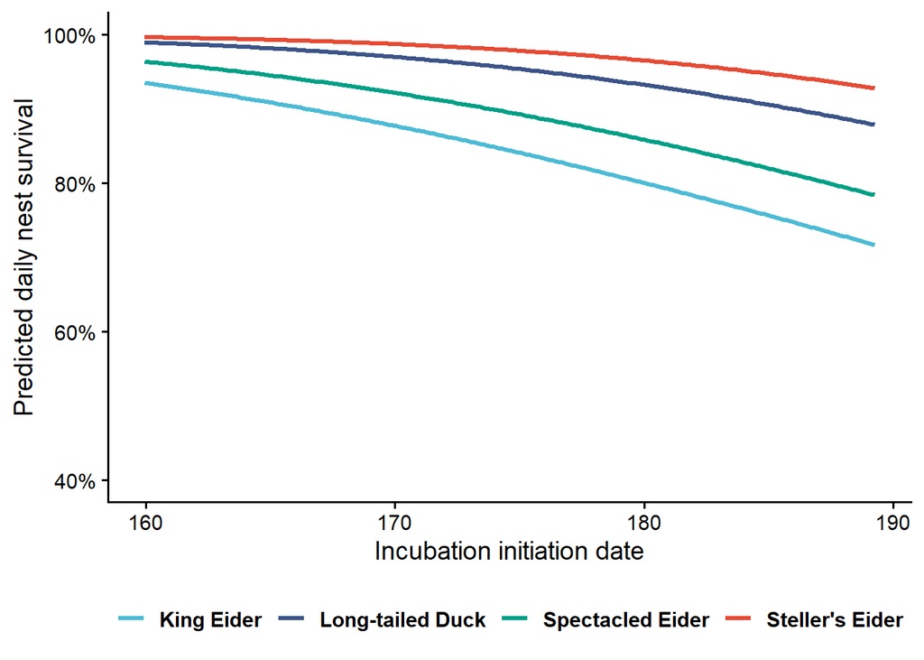

```r
# supporting figure
# Predicted daily nest survival vs incubation initiation.
# pick best model
m_best <- glm_mods[["incinit_species"]]

# inverse cloglog -> daily survival
inv_cloglog <- function(eta) 1 - exp(-exp(eta))

# model Species levels (critical: must match fit)
species_levels <- m_best$xlevels$Species
if (is.null(species_levels)) species_levels <- levels(m_best$model$Species)

# build an initiation grid on the ORIGINAL scale, then convert to z using le_dat params
inc_mu <- mean(le_dat$inc_init_final, na.rm = TRUE)
inc_sd <- sd(le_dat$inc_init_final, na.rm = TRUE)

inc_grid <- seq(
  quantile(le_dat$inc_init_final, 0.02, na.rm = TRUE),
  quantile(le_dat$inc_init_final, 0.98, na.rm = TRUE),
  length.out = 160
)

# exposure = 1 day => log_exposure = 0
newdat <- expand_grid(
  Species = factor(species_levels, levels = species_levels),
  inc_init_final = inc_grid
) %>%
  mutate(
    z_inc_init   = (inc_init_final - inc_mu) / inc_sd,
    log_exposure = 0
  )

# predict on link scale, then transform
pr <- predict(m_best, newdata = newdat, type = "link", se.fit = TRUE)

fig_dat <- newdat %>%
  mutate(
    eta    = pr$fit,
    se     = pr$se.fit,
    lo_eta = eta - 1.96 * se,
    hi_eta = eta + 1.96 * se,
    S_day  = inv_cloglog(eta),
    lo     = inv_cloglog(lo_eta),
    hi     = inv_cloglog(hi_eta)
  )

# plot
fig_init <- ggplot(fig_dat, aes(x = inc_init_final, y = S_day,
                                color = Species, fill = Species)) +
  geom_line(linewidth = 1.2) +
  scale_color_manual(values = palette, labels = species_labels) +
  scale_fill_manual(values = palette, labels = species_labels) +
  scale_y_continuous(limits = c(0.4, 1),
                     labels = percent_format(accuracy = 1)) +
  labs(
    x = "Incubation initiation date",
    y = "Predicted daily nest survival",
  ) +
  theme_classic(base_size = 14) +
  theme(
    legend.position = "bottom",
    legend.title = element_blank(),
    legend.text = element_text(face = "bold")
)

fig_init
```

```r
ggsave(
  "Fig6.png",
  plot = fig_init,
  width = 7,
  height = 5,
  units = "in",
  dpi = 300,
  bg = "white"
)
```

**Figure 6.** Predicted daily nest survival as a function of incubation initiation date for four Arctic-breeding sea ducks near Utqiaġvik, Alaska between 2011-2025. Lines show species-specific model predictions, illustrating declining daily nest survival with later incubation initiation. On the x-axis, days range from 160 (June 9) and 190 (July 9).

**Best-fit model diagnostics**

```r
# choose best supported model, w/ name
glm_tab_clean <- glm_tab %>% filter(ok, is.finite(AICc)) %>% arrange(AICc)
best_name <- glm_tab_clean$model[1]
m_best_le <- glm_mods[[best_name]]

best_name
```

```
[1] "incinit_species"
```

```r
summary(m_best_le)
```

```
Call:
glm(formula = formula, family = binomial(link = "cloglog"), data = le_dat)

Coefficients:
            Estimate Std. Error z value Pr(>|z|)
(Intercept)  0.67477    0.12339   5.469 4.54e-08 ***
z_inc_init  -0.17119    0.07207  -2.375 0.017540 *
SpeciesLTDU  0.51451    0.20201   2.547 0.010866 *
SpeciesSPEI  0.19397    0.15274   1.270 0.204118
SpeciesSTEI  0.73651    0.19626   3.753 0.000175 ***
---
Signif. codes:  0 '***' 0.001 '**' 0.01 '*' 0.05 '.' 0.1 ' ' 1

(Dispersion parameter for binomial family taken to be 1)

    Null deviance: 313.91  on 732  degrees of freedom
Residual deviance: 294.68  on 728  degrees of freedom
AIC: 304.68

Number of Fisher Scoring iterations: 7
```

```r
summary(le_dat$exposure_days)
```

```
   Min. 1st Qu.  Median    Mean 3rd Qu.    Max.
  1.000   1.000   1.000   1.277   1.000   6.000
```

```r
quantile(le_dat$exposure_days, probs = c(0, .05, .25, .5, .75, .95, 1), na.rm = TRUE)
```

```
  0%   5%  25%  50%  75%  95% 100%
   1    1    1    1    1    3    6
```

```r
# Event rate by species
le_dat %>%
  group_by(Species) %>%
  summarise(
    n_int = n(),
    events = sum(alive_next == 0),
    event_rate = mean(alive_next == 0),
    .groups = "drop"
  )
```

```
# A tibble: 4 × 4
  Species n_int events event_rate
  <fct>   <int>  <int>      <dbl>
1 KIEI      160      8     0.05
2 LTDU      126      7     0.0556
3 SPEI      255      8     0.0314
4 STEI      192      5     0.0260
```

```r
# convergence / numerical stability
summary(m_best_le)$coefficients
```

```
              Estimate Std. Error   z value     Pr(>|z|)
(Intercept)  0.6747665 0.12339086  5.468529 4.537850e-08
z_inc_init  -0.1711873 0.07207324 -2.375185 1.754015e-02
SpeciesLTDU  0.5145100 0.20200863  2.546970 1.086627e-02
SpeciesSPEI  0.1939715 0.15274462  1.269907 2.041177e-01
SpeciesSTEI  0.7365085 0.19626067  3.752706 1.749362e-04
```

```r
# Check for very large coefficients / SEs
coef_table <- broom::tidy(m_best_le)
coef_table %>% arrange(desc(abs(estimate))) %>% head(10)
```

```
# A tibble: 5 × 5
  term        estimate std.error statistic      p.value
  <chr>          <dbl>     <dbl>     <dbl>        <dbl>
1 SpeciesSTEI    0.737    0.196       3.75 0.000175
2 (Intercept)    0.675    0.123       5.47 0.0000000454
3 SpeciesLTDU    0.515    0.202       2.55 0.0109
4 SpeciesSPEI    0.194    0.153       1.27 0.204
5 z_inc_init    -0.171    0.0721     -2.38 0.0175
```

```r
coef_table %>% arrange(desc(std.error)) %>% head(10)
```

```
# A tibble: 5 × 5
  term        estimate std.error statistic      p.value
  <chr>          <dbl>     <dbl>     <dbl>        <dbl>
1 SpeciesLTDU    0.515    0.202       2.55 0.0109
2 SpeciesSTEI    0.737    0.196       3.75 0.000175
3 SpeciesSPEI    0.194    0.153       1.27 0.204
4 (Intercept)    0.675    0.123       5.47 0.0000000454
5 z_inc_init    -0.171    0.0721     -2.38 0.0175
```

```r
# Check dispersion/overdispersion due to clustering (intervals within nests)
performance::check_overdispersion(m_best_le)
```

```
# Overdispersion test

 dispersion ratio = 0.767
          p-value =  0.04
```

```r
# compute a simple dispersion ratio (Pearson chi-square / df)
pearson_dispersion <- function(m) {
  rp <- residuals(m, type = "pearson")
  chisq <- sum(rp^2)
  df <- df.residual(m)
  tibble(chisq = chisq, df = df, dispersion = chisq / df)
}
pearson_dispersion(m_best_le)
```

```
# A tibble: 1 × 3
    chisq    df dispersion
    <dbl> <int>      <dbl>
1 139910.   728       192.
```

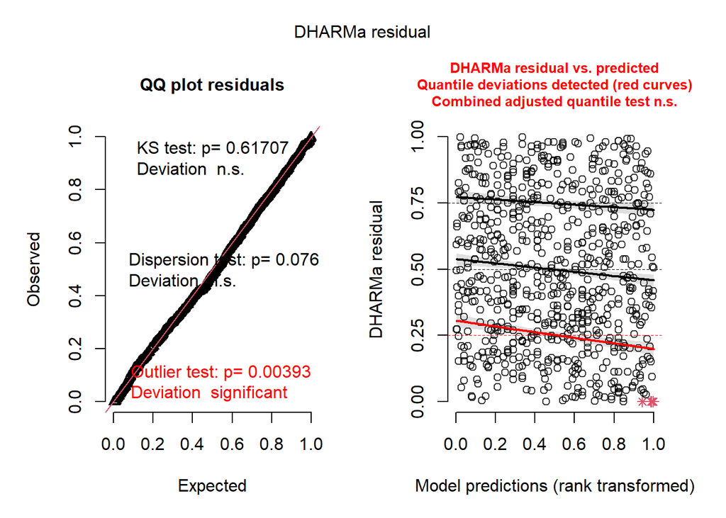

```r
# If dispersion > 1.2, consider cluster-robust SEs

# simulation-based residual diagnostics
set.seed(1)
sim <- DHARMa::simulateResiduals(fittedModel = m_best_le, n = 1000)
plot(sim)
```

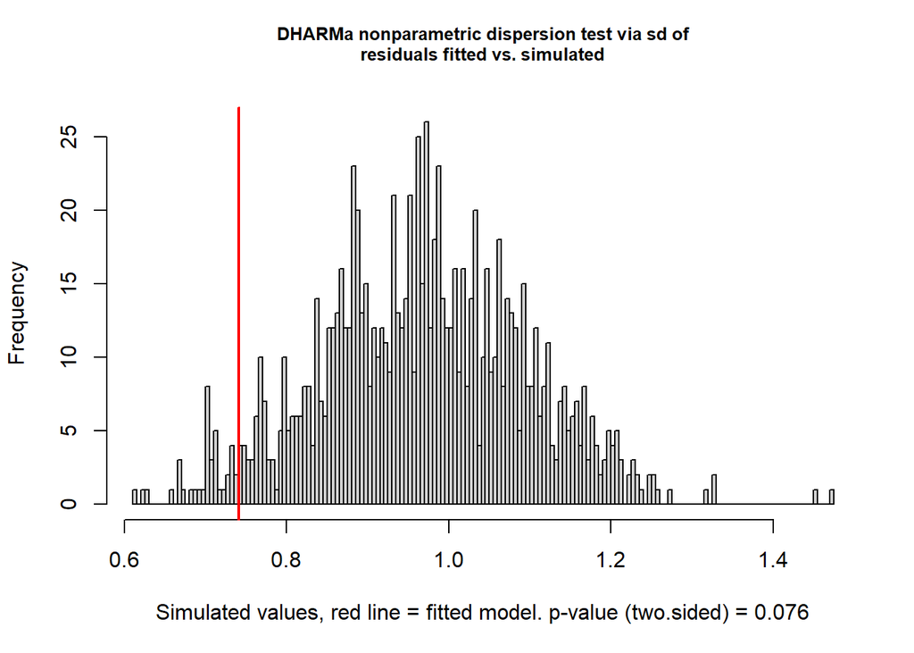

```
    DHARMa nonparametric dispersion test via sd of residuals fitted vs.
    simulated

data:  simulationOutput
dispersion = 0.76614, p-value = 0.076
alternative hypothesis: two.sided
```

```r
DHARMa::testDispersion(sim)
```

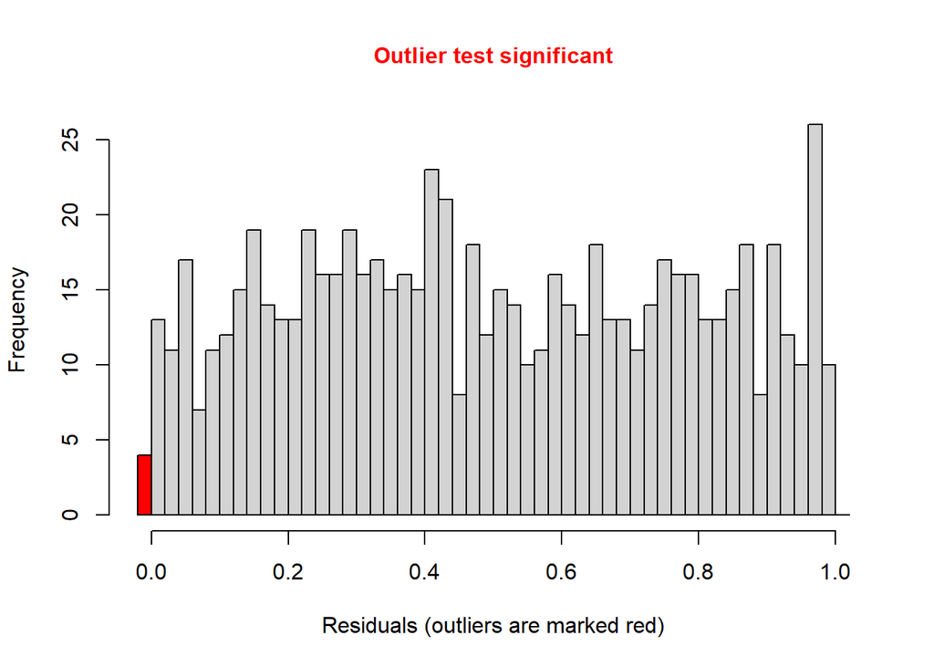

```
    DHARMa outlier test based on exact binomial test with approximate
    expectations

data:  sim
outliers at both margin(s) = 6, observations = 733, p-value = 0.00393
alternative hypothesis: true probability of success is not equal to 0.001998002
95 percent confidence interval:
 0.003009702 0.017730794
sample estimates:
frequency of outliers (expected: 0.001998001998002 )
                                         0.008185539
```

```r
DHARMa::testOutliers(sim)
```

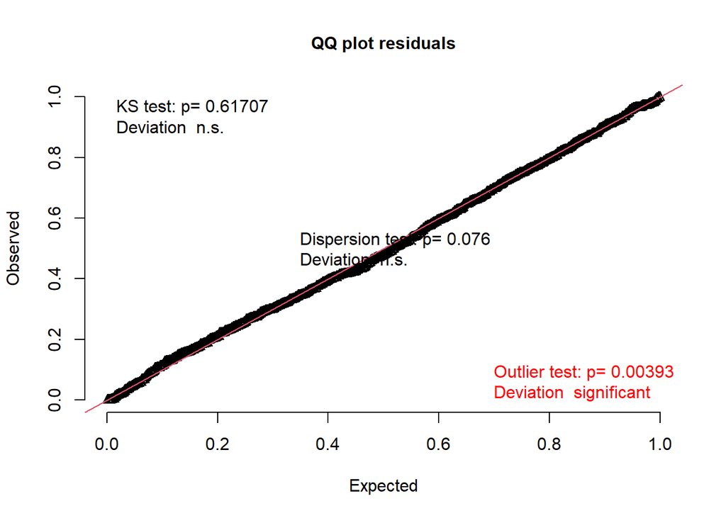

```
    Asymptotic one-sample Kolmogorov-Smirnov test

data:  simulationOutput$scaledResiduals
D = 0.027924, p-value = 0.6171
alternative hypothesis: two-sided
```

```r
DHARMa::testUniformity(sim)
```

```r
# Collinearity among predictors
car::vif(m_best_le)
```

```
               GVIF Df GVIF^(1/(2*Df))
z_inc_init 1.749709  1        1.322766
Species    1.749709  3        1.097727
```

```r
# check simple correlations among numeric covariates you use together:
le_dat %>%
  select(z_DOY, z_constancy, z_recesses, z_inc_init) %>%
  cor(use = "pairwise.complete.obs")
```

```
                 z_DOY z_constancy z_recesses z_inc_init
z_DOY        1.0000000  -0.2672229  0.4610934  0.6017590
z_constancy -0.2672229   1.0000000 -0.5667850 -0.3547490
z_recesses   0.4610934  -0.5667850  1.0000000  0.3923098
z_inc_init   0.6017590  -0.3547490  0.3923098  1.0000000
```

```r
# Check clustering / non-independence by Nest_ID
# Because intervals are nested within Nest_ID, residuals may be correlated.
# average DHARMa residuals by nest should be centered ~0.5.
res_by_nest <- tibble(
  Nest_ID = le_dat$Nest_ID,
  simres  = sim$scaledResiduals
) %>%
  group_by(Nest_ID) %>%
  summarise(mean_resid = mean(simres), n_int = n(), .groups = "drop")

summary(res_by_nest$mean_resid)
```

```
   Min. 1st Qu.  Median    Mean 3rd Qu.    Max.
0.01579 0.41724 0.49761 0.48194 0.57815 0.76686
```

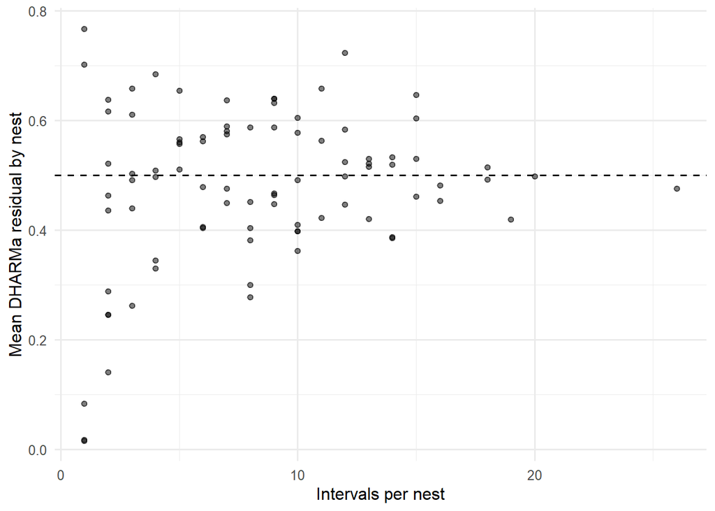

```r
ggplot(res_by_nest, aes(x = n_int, y = mean_resid)) +
  geom_point(alpha = 0.5) +
  geom_hline(yintercept = 0.5, linetype = 2) +
  labs(x = "Intervals per nest", y = "Mean DHARMa residual by nest") +
  theme_minimal(base_size = 12)
```

```r
# Effect, coefficient, standard error table

m <- m_best_le

# model pieces
X <- model.matrix(m)
u <- residuals(m, type = "response")
mu <- fitted(m)
nest <- le_dat$Nest_ID

stopifnot(nrow(X) == length(u), nrow(X) == length(nest))

# (X' W X)^-1
W <- as.numeric(mu * (1 - mu))
XtW <- t(X) * W
bread <- solve(XtW %*% X)

# Clustered score outer products
idx_by_cluster <- split(seq_len(nrow(X)), nest)

S <- vapply(
  idx_by_cluster,
  function(idx) colSums(X[idx, , drop = FALSE] * u[idx]),
  FUN.VALUE = numeric(ncol(X))
)

meat <- S %*% t(S)

# CR1 small-sample correction
G <- length(idx_by_cluster)
N <- nrow(X)
p <- ncol(X)
dfc <- (G / (G - 1)) * ((N - 1) / (N - p))

V_cr <- dfc * (bread %*% meat %*% bread)

# Coefficients  and robust SEs
b <- coef(m)

se <- sqrt(diag(V_cr))
names(se) <- colnames(X)
se <- se[names(b)]

tab <- tibble(
  term = names(b),
  coef = as.numeric(b),
  se   = as.numeric(se)
)

# Label effects via named-vector lookup
effect_labels <- c(
  "(Intercept)" = "Intercept",
  "z_inc_init"  = "Incubation initiation date",
  "SpeciesLTDU" = "  Long-tailed Duck",
  "SpeciesSPEI" = "  Spectacled Eider",
  "SpeciesSTEI" = "  Steller's Eider"
)

tab <- tab %>%
  mutate(
    Effect = ifelse(term %in% names(effect_labels),
                    effect_labels[term],
                    term)
  ) %>%
  select(Effect, coef, se)

# table formatting

# row order
tab <- tab %>%
  mutate(
    Effect = factor(
      Effect,
      levels = c(
        "Intercept",
        "  Long-tailed Duck",
        "  Spectacled Eider",
        "  Steller's Eider",
        "Incubation initiation date"
      )
    )
  ) %>%
  arrange(Effect) %>%
  mutate(Effect = as.character(Effect))

# build pub-quality table

table_input <- tab %>%
  transmute(
    Effect = Effect,
    Coefficient = coef,
    `Standard error` = se
  ) %>%
  filter(!is.na(Effect))

Table_coefficients <- gt::gt(table_input) %>%
  gt::fmt_number(columns = c("Coefficient", "Standard error"), decimals = 3) %>%
  gt::fmt_missing(columns = c("Coefficient", "Standard error"), missing_text = "") %>%
  gt::cols_align(align = "left",   columns = "Effect") %>%
  gt::cols_align(align = "center", columns = c("Coefficient", "Standard error")) %>%
  gt::tab_style(
    style = gt::cell_text(weight = "bold"),
    locations = gt::cells_body(rows = Effect %in% c("Intercept", "Incubation initiation date"))
  ) %>%
  gt::tab_options(
    table.font.size = gt::px(12),
    data_row.padding = gt::px(2),
    table.border.top.style = "solid",
    table.border.bottom.style = "solid",
    column_labels.border.bottom.style = "solid",
    table_body.hlines.style = "none"
  )

Table_coefficients
```

| Effect | Coefficient | Standard error |
| --- | --- | --- |
| Intercept | 0.675 | 0.451 |
| Long-tailed Duck | 0.515 | 0.676 |
| Spectacled Eider | 0.194 | 0.494 |
| Steller's Eider | 0.737 | 0.554 |
| Incubation initiation date | −0.171 | 0.219 |

```r
# export table for manuscript
gtsave(
  Table_coefficients,
  filename = "Table6.png",
  vwidth  = 900,
  vheight = 300
)
```

**Table 6.** Coefficient estimates and standard errors from logistic exposure model relating daily nest survival to incubation initiation date for Arctic-breeding sea ducks near Utqiaġvik, Alaska between 2011-2025. The intercept represents *S. spectabilis*, with coefficients for other species expressed as deviations from this reference category.

**Key Model Takeaways**